# Problem Set 1 Example Answers

Instructor data suitability check

```r
library(dplyr)
library(ggplot2)
library(here)
library(readr)

here::i_am("course_docs/instructor_examples/problem-set-1-example-answers.qmd")

prams <- read_csv(here::here("data", "real", "prams_2011_selected.csv"))
census_long <- read_csv(here::here("data", "real", "census_state_race_ethnicity_long.csv"))
state_ranks <- read_csv(here::here("data", "real", "state_population_ranks.csv"))
race_summary <- read_csv(here::here("data", "real", "state_race_population_summary.csv"))
```

# Task 1: Dataset Orientation

For the Census race/ethnicity dataset, one row represents one race/ethnicity category within one state. The main variables used below are `state_name`, `race_ethnicity`, `race_ethnicity_population`, `total_population`, and `share`.

A key caution is that the plotted shares are state-level summaries. They describe population composition by state, not individual people.

```r
census_long |>
  select(state_name, race_ethnicity, race_ethnicity_population, total_population, share) |>
  head(10)
```

```
# A tibble: 10 × 5
   state_name    race_ethnicity  race_ethnicity_popul…¹ total_population   share
   <chr>         <chr>                            <dbl>            <dbl>   <dbl>
 1 Massachusetts American India…                   9387          6892503 1.40e-3
 2 Massachusetts Asian                           504900          6892503 7.53e-2
 3 Massachusetts Black                           457055          6892503 6.82e-2
 4 Massachusetts Hispanic or La…                 887685          6892503 1.32e-1
 5 Massachusetts Native Hawaiia…                   1607          6892503 2.40e-4
 6 Massachusetts Other                            92108          6892503 1.37e-2
 7 Massachusetts White                          4748897          6892503 7.09e-1
 8 Hawaii        American India…                   2321          1415872 2.00e-3
 9 Hawaii        Asian                           531558          1415872 4.57e-1
10 Hawaii        Black                            21877          1415872 1.88e-2
# ℹ abbreviated name: ¹race_ethnicity_population
```

# Task 2: Counts, Composition, Or Rank

This plot uses `state_population_ranks.csv` to show the twelve largest states in this dataset.

[figure not shown]

```r
top_states <- state_ranks |>
  slice_max(population, n = 12) |>
  mutate(state_name = reorder(state_name, population))

p1 <- ggplot(top_states, aes(x = state_name, y = population)) +
  geom_col(fill = "steelblue") +
  coord_flip() +
  labs(
    title = "Largest States In The Population Rank Dataset",
    x = NULL,
    y = "Population"
  ) +
  theme_minimal()

p1
```

The plot makes the rank comparison easy: the largest states are clearly separated from the smaller states in the top twelve. This is a suitable categorical/rank task because each bar represents one state and the bar length represents population.

# Task 3: Distribution Or Grouped Summary

This plot uses the PRAMS dataset to compare distributions of alcohol-use estimates across several subgroup categories.

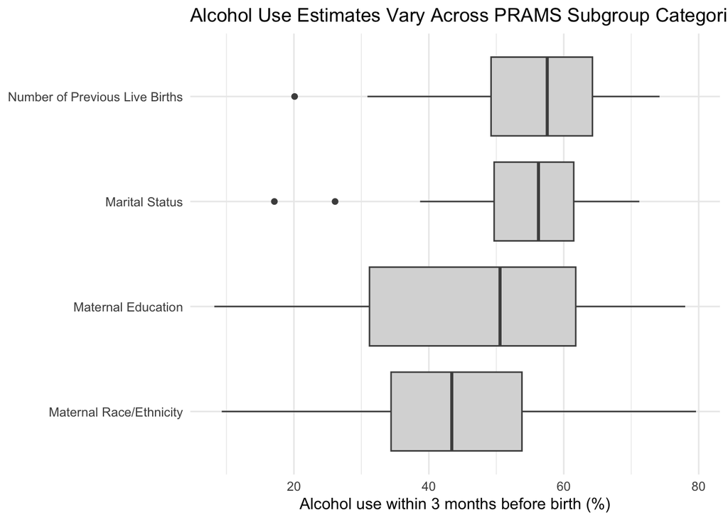

```r
selected_prams_groups <- prams |>
  filter(
    subgroup_cat %in% c(
      "Maternal Race/Ethnicity",
      "Maternal Education",
      "Marital Status",
      "Number of Previous Live Births"
    ),
    !is.na(alcohol_use_within_3_months_birth)
  ) |>
  mutate(subgroup_cat = reorder(subgroup_cat, alcohol_use_within_3_months_birth, median))

p2 <- ggplot(
  selected_prams_groups,
  aes(x = subgroup_cat, y = alcohol_use_within_3_months_birth)
) +
  geom_boxplot(fill = "gray85", color = "gray30") +
  coord_flip() +
  labs(
    title = "Alcohol Use Estimates Vary Across PRAMS Subgroup Categories",
    x = NULL,
    y = "Alcohol use within 3 months before birth (%)"
  ) +
  theme_minimal()

p2
```

Each plotted value is a PRAMS state/subgroup percentage, not a person-level observation. The plot is useful for checking center, spread, and possible outlying estimates across subgroup categories.

# Task 4: Association Or Comparison Across Groups

This plot uses `state_race_population_summary.csv` to examine whether larger states in this dataset tend to have different Hispanic/Latino population shares.

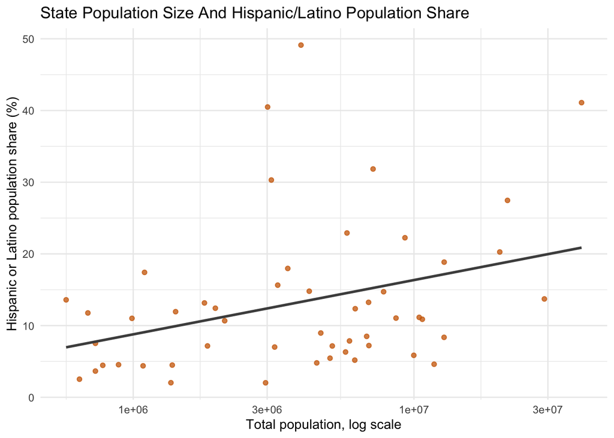

```r
race_association <- race_summary |>
  mutate(hispanic_or_latino_share_percent = share_hispanic_or_latino * 100)

p3 <- ggplot(
  race_association,
  aes(x = total_population, y = hispanic_or_latino_share_percent)
) +
  geom_point(alpha = 0.75, color = "darkorange3") +
  geom_smooth(method = "lm", se = FALSE, color = "gray30") +
  scale_x_log10() +
  labs(
    title = "State Population Size And Hispanic/Latino Population Share",
    x = "Total population, log scale",
    y = "Hispanic or Latino population share (%)"
  ) +
  theme_minimal()

p3
```

This plot suggests whether population size and Hispanic/Latino population share move together in these state-level summaries. It should not be read as an individual-level relationship or a causal claim.

# Task 5: Reflection

The PRAMS boxplot was the most useful exploratory figure in this example because it showed that the spread of estimates differs across subgroup categories. The next question would be whether particular subgroup values drive that spread within specific states.

# Data Suitability Notes

- The assigned datasets support the required tasks.
- `state_population_ranks.csv` works well for rank and ordered categorical plots.
- `prams_2011_selected.csv` works well for distribution and grouped-summary plots, as long as students state that values are pre-aggregated percentages.
- `state_race_population_summary.csv` works well for association plots across state-level summaries.
- `census_state_race_ethnicity_long.csv` works well for orientation and composition tasks.